# #TidyTuesday week 43, Хорор филмови

novica

22/10/2019

Libraries

```r
library(tidyverse)
```

Load the data

```r
horror_movies <- readr::read_csv("https://raw.githubusercontent.com/rfordatascience/tidytuesday/master/data/2019/2019-10-22/horror_movies.csv")
```

```r
glimpse(horror_movies)
```

```
## Observations: 3,328
## Variables: 12
## $ title             <chr> "Gut (2012)", "The Haunting of Mia Moss (2017)", "S…
## $ genres            <chr> "Drama| Horror| Thriller", "Horror", "Horror", "Com…
## $ release_date      <chr> "26-Oct-12", "13-Jan-17", "21-Oct-17", "23-Apr-13",…
## $ release_country   <chr> "USA", "USA", "Canada", "USA", "USA", "UK", "USA", …
## $ movie_rating      <chr> NA, NA, NA, "NOT RATED", NA, NA, "NOT RATED", NA, "…
## $ review_rating     <dbl> 3.9, NA, NA, 3.7, 5.8, NA, 5.1, 6.5, 4.6, 5.4, 5.3,…
## $ movie_run_time    <chr> "91 min", NA, NA, "82 min", "80 min", "93 min", "90…
## $ plot              <chr> "Directed by Elias. With Jason Vail, Nicholas Wilde…
## $ cast              <chr> "Jason Vail|Nicholas Wilder|Sarah Schoofs|Kirstiann…
## $ language          <chr> "English", "English", "English", "English", "Italia…
## $ filming_locations <chr> "New York, USA", NA, "Sudbury, Ontario, Canada", "B…
## $ budget            <chr> NA, "$30,000", NA, NA, NA, "$3,400,000", NA, NA, NA…
```

# Што треба да се поправи во податоците?

# Идеи за графици?

- Wordcloud за plot?
- Мапа на локации за снимање?
- Однос помеѓу под-жанрови и буџет, времетраење на филм, и рејтинг

# Wordcloud за заплетот на филмовите

```r
#install.packages('ggwordcloud')
#install.packages("tidytext")
#there are alternatives: wordcloud and tm

library(ggwordcloud)
library(tidytext)
```

```r
txtplot <- horror_movies %>%
  select(matches("plot")) %>%
  unnest_tokens(word, plot) %>%
  dplyr::count(word, sort = TRUE)
```

Чистење на податоците од т.н. stop words и бројки

```r
data("stop_words")
txtplot_clean <- txtplot %>%
  anti_join(stop_words)
```

```r
#using datapasta
popnames <- tibble::tribble(
                    ~Rank,         ~MName,   ~MNumber,       ~WName,   ~WNumber,
                        1,       "James",   4764644,      "Mary",   3328565,
                        2,        "John",   4546819,  "Patricia",   1562727,
                        3,      "Robert",   4535897,  "Jennifer",   1466854,
                        4,     "Michael",   4323074,     "Linda",   1448194,
                        5,     "William",   3631876, "Elizabeth",   1436232,
                        6,       "David",   3560660,   "Barbara",   1406173,
                        7,     "Richard",   2477879,     "Susan",   1105188,
                        8,      "Joseph",   2367801,   "Jessica",   1044492,
                        9,      "Thomas",   2167014,     "Sarah",    995436,
                       10,     "Charles",   2124748,     "Karen",    985261,
                       11, "Christopher",   2025963,     "Nancy",    971838,
                       12,      "Daniel",   1882400,  "Margaret",    968332,
                       13,     "Matthew",   1591773,      "Lisa",    964705,
                       14,     "Anthony",   1400849,     "Betty",    948725,
                       15,      "Donald",   1357533,   "Dorothy",    878637,
                       16,        "Mark",   1345366,    "Sandra",    873403,
                       17,        "Paul",   1296573,    "Ashley",    845462,
                       18,      "Steven",   1279636,  "Kimberly",    836685,
                       19,      "Andrew",   1248926,     "Donna",    824044,
                       20,     "Kenneth",   1231665,     "Emily",    820233,
                       21,      "Joshua",   1208231,  "Michelle",    810244,
                       22,      "George",   1181255,     "Carol",    808228,
                       23,       "Kevin",   1169693,    "Amanda",    772427,
                       24,       "Brian",   1165284,   "Melissa",    752207,
                       25,      "Edward",   1114165,   "Deborah",    739570,
                       26,      "Ronald",   1073235, "Stephanie",    737514,
                       27,     "Timothy",   1067263,   "Rebecca",    729638,
                       28,       "Jason",   1031730,     "Laura",    723960,
                       29,     "Jeffrey",    974219,    "Sharon",    720799,
                       30,        "Ryan",    931422,   "Cynthia",    705556,
                       31,       "Jacob",    915562,  "Kathleen",    691649,
                       32,        "Gary",    899587,     "Helen",    685877,
                       33,    "Nicholas",    888450,       "Amy",    679793,
                       34,        "Eric",    875444,   "Shirley",    671283,
                       35,     "Stephen",    840568,    "Angela",    657793,
                       36,    "Jonathan",    838634,      "Anna",    639947,
                       37,       "Larry",    802473,    "Brenda",    606269,
                       38,      "Justin",    774858,    "Pamela",    592685,
                       39,       "Scott",    769294,    "Nicole",    586880,
                       40,     "Brandon",    756415,      "Ruth",    586566,
                       41,       "Frank",    722122, "Katherine",    577232,
                       42,    "Benjamin",    719558,  "Samantha",    572632,
                       43,     "Gregory",    706323, "Christine",    565140,
                       44,      "Samuel",    705094,      "Emma",    557929,
                       45,     "Raymond",    690233, "Catherine",    557454,
                       46,     "Patrick",    662614,     "Debra",    548270,
                       47,   "Alexander",    656997,  "Virginia",    546942,
                       48,        "Jack",    636163,    "Rachel",    546198,
                       49,      "Dennis",    611399,   "Carolyn",    543284,
                       50,       "Jerry",    603209,     "Janet",    543129
                    )


popnames_long <- popnames %>%
  select(contains("Name")) %>%
  pivot_longer(c("MName", "WName"), names_to = "type", values_to = "word") %>%
  select(-"type") %>%
  map_df(., str_to_lower)
```

```r
txtplot_clean <- txtplot_clean %>%
  anti_join(popnames_long, by = "word")
```

```r
# remove numbers
nums <-  txtplot_clean %>%
  filter(str_detect(word, "^[0-9]")) %>%
  select(word) %>%
  unique()

txtplot_clean <- txtplot_clean %>%
  anti_join(nums, by = "word")
```

```r
# remove unique stop words that snuck in there
uni_sw <- data.frame(word = c("directed", "film", "horror", "michael","john", "david", "james",
                              "robert", "tom", "adam", "bryan", "scott", "joe", "ryan", "lee",
                              "patrick", "de", "alex", "matt", "tony", "josh", "chris", "mike"))

txtplot_clean <- txtplot_clean %>%
  anti_join(uni_sw, by = "word")
```

#Plot the the horror plots

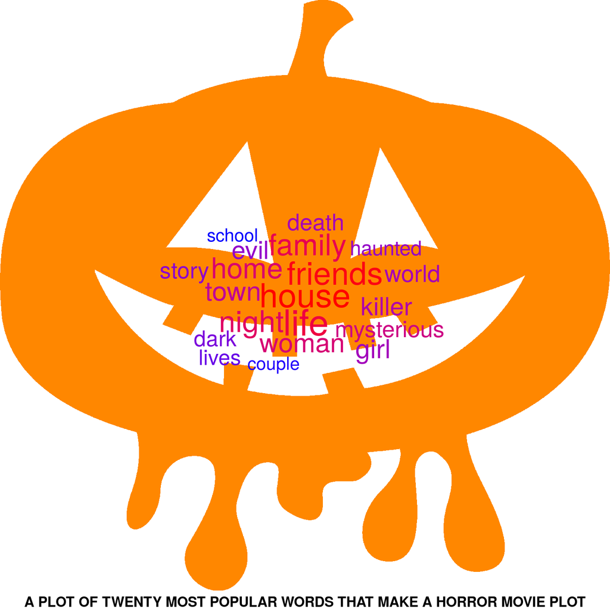

```r
words_to_plot <-  top_n(txtplot_clean, 20, wt = n)

img <- png::readPNG("./hp.png")

ggplot(words_to_plot) +
  aes(label = word) +
  aes(size = n, color = n) +
  ggpubr::background_image(img) +
  #geom_text_wordcloud() +
  geom_text_wordcloud_area(shape = "pentagon") +
  scale_size_area(max_size = 12) +
  theme_void() +
  scale_color_gradient(low = "blue", high = "red") +
  labs(caption = "A PLOT OF TWENTY MOST POPULAR WORDS THAT MAKE A HORROR MOVIE PLOT") +
  theme(plot.caption = element_text(face = "bold", hjust = 0.5, size = rel(1.2)))
```

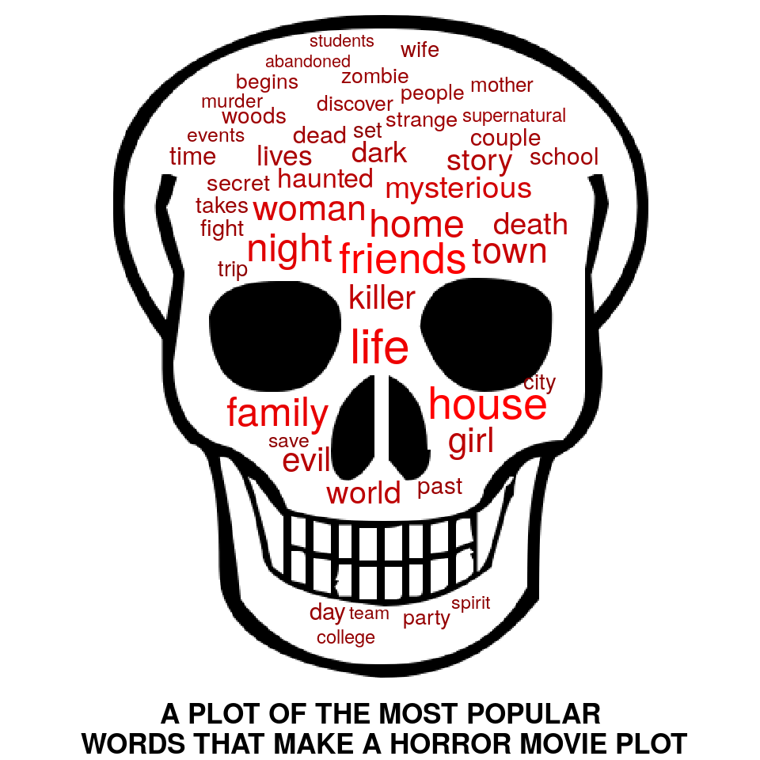

```r
words_to_skull <-  top_n(txtplot_clean, 60, wt = n)

img <- png::readPNG("./skull-lines.png")

ggplot(words_to_skull) +
  aes(label = word) +
  aes(size = n, color = n) +
  ggpubr::background_image(img) +
  geom_text_wordcloud_area(
    mask = png::readPNG("./skull.png"),
    rm_outside = TRUE) +
  scale_size_area(max_size = 8) +
  theme_void() +
  scale_color_gradient(low = "darkred", high = "red") +
  labs(caption = "A PLOT OF THE MOST POPULAR\n WORDS THAT MAKE A HORROR MOVIE PLOT") +
  theme(plot.caption = element_text(face = "bold", hjust = 0.5, size = rel(1.2)))
```

## Ratings

How do budget and rating relate to genres? Is a horror movie more likely to be highly rated if it is also a comedy vs. drama vs. thriller.

```r
# first, a list of unique genres
(
  genres <- horror_movies %>%
    pull(genres) %>%
    str_split(pattern = "\\| ") %>%
    unlist %>%
    sort %>%
    unique
)
```

```
##  [1] "Action"     "Adult"      "Adventure"  "Animation"  "Biography"
##  [6] "Comedy"     "Crime"      "Drama"      "Family"     "Fantasy"
## [11] "History"    "Horror"     "Music"      "Musical"    "Mystery"
## [16] "Reality-TV" "Romance"    "Sci-Fi"     "Sport"      "Thriller"
## [21] "War"        "Western"
```

There are many subgenres, so do a count and take the most common ones (keep subgenres with at least 100 movies)

```r
(
  common_genres <- horror_movies %>%
    pull(genres) %>%
    str_split(pattern = "\\| ") %>%
    unlist %>%
    table %>%
    as_tibble() %>%
    arrange(desc(n)) %>%
    filter(n > 100) %>%
    pull(1)
)
```

```
##  [1] "Horror"    "Thriller"  "Drama"     "Comedy"    "Mystery"   "Action"
##  [7] "Sci-Fi"    "Fantasy"   "Crime"     "Adventure"
```

Now add 10 columns to the horror_movies dataset

```r
for (i in seq_along(common_genres)) {
  horror_movies[[common_genres[i]]] <-
    ifelse(str_detect(horror_movies$genres, common_genres[i]), common_genres[i], NA)
}

glimpse(horror_movies)
```

```
## Observations: 3,328
## Variables: 22
## $ title             <chr> "Gut (2012)", "The Haunting of Mia Moss (2017)", "S…
## $ genres            <chr> "Drama| Horror| Thriller", "Horror", "Horror", "Com…
## $ release_date      <chr> "26-Oct-12", "13-Jan-17", "21-Oct-17", "23-Apr-13",…
## $ release_country   <chr> "USA", "USA", "Canada", "USA", "USA", "UK", "USA", …
## $ movie_rating      <chr> NA, NA, NA, "NOT RATED", NA, NA, "NOT RATED", NA, "…
## $ review_rating     <dbl> 3.9, NA, NA, 3.7, 5.8, NA, 5.1, 6.5, 4.6, 5.4, 5.3,…
## $ movie_run_time    <chr> "91 min", NA, NA, "82 min", "80 min", "93 min", "90…
## $ plot              <chr> "Directed by Elias. With Jason Vail, Nicholas Wilde…
## $ cast              <chr> "Jason Vail|Nicholas Wilder|Sarah Schoofs|Kirstiann…
## $ language          <chr> "English", "English", "English", "English", "Italia…
## $ filming_locations <chr> "New York, USA", NA, "Sudbury, Ontario, Canada", "B…
## $ budget            <chr> NA, "$30,000", NA, NA, NA, "$3,400,000", NA, NA, NA…
## $ Horror            <chr> "Horror", "Horror", "Horror", "Horror", "Horror", "…
## $ Thriller          <chr> "Thriller", NA, NA, "Thriller", NA, "Thriller", "Th…
## $ Drama             <chr> "Drama", NA, NA, NA, "Drama", NA, "Drama", "Drama",…
## $ Comedy            <chr> NA, NA, NA, "Comedy", NA, NA, NA, NA, NA, "Comedy",…
## $ Mystery           <chr> NA, NA, NA, NA, NA, NA, NA, NA, "Mystery", NA, NA, …
## $ Action            <chr> NA, NA, NA, NA, NA, NA, NA, "Action", NA, NA, NA, N…
## $ `Sci-Fi`          <chr> NA, NA, NA, NA, NA, NA, NA, "Sci-Fi", NA, NA, NA, N…
## $ Fantasy           <chr> NA, NA, NA, NA, NA, NA, NA, NA, NA, NA, NA, NA, NA,…
## $ Crime             <chr> NA, NA, NA, NA, "Crime", NA, NA, NA, NA, NA, NA, NA…
## $ Adventure         <chr> NA, NA, NA, NA, NA, NA, NA, NA, NA, NA, NA, "Advent…
```

# Now we can convert to long format such that we have one column for the different genres after parsing

```r
hm <-
  horror_movies %>%
  pivot_longer(cols = common_genres,
               names_to = "parsed_genres",
               values_to = "parsed_values")
```

# Plot:

Review ratings

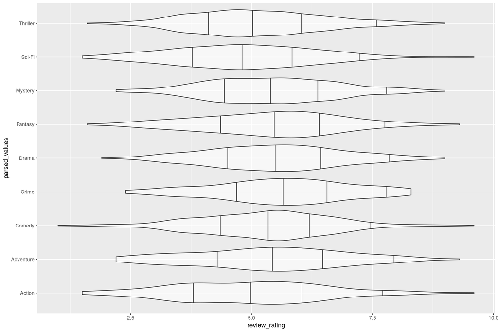

```r
# filter for only secondary genres
hm %>% filter(!is.na(parsed_values), !parsed_values == "Horror") %>%
  ggplot(data = .) +
  aes(x = parsed_values) +
  aes(y = review_rating) +
  geom_violin(alpha = .6, draw_quantiles = c(0.95, 0.75, 0.5, 0.25, 0.5), trim = TRUE) +
  coord_flip()
```

Movie run time

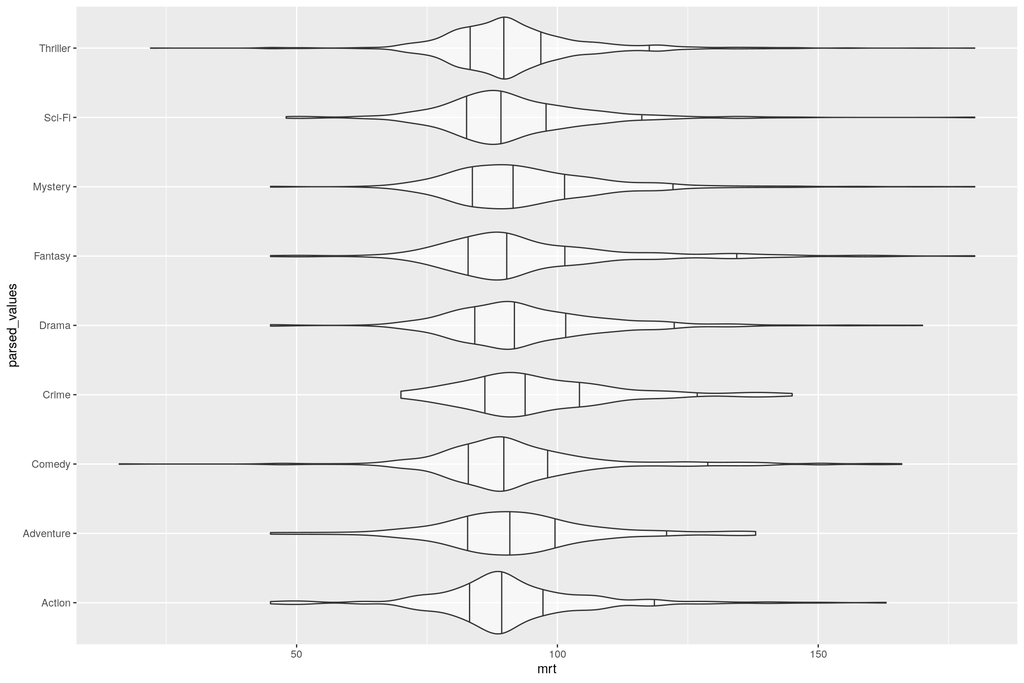

```r
# filter for only secondary genres
hm %>% filter(!is.na(parsed_values), !parsed_values == "Horror") %>%
  mutate(mrt = str_remove(movie_run_time, " min") %>% as.numeric()) %>%
  ggplot(data = .) +
  aes(x = parsed_values) +
  aes(y = mrt) +
  geom_violin(alpha = .6, draw_quantiles = c(0.95, 0.75, 0.5, 0.25, 0.5), trim = TRUE) +
  coord_flip()
```

Budget, needs to be cleaned

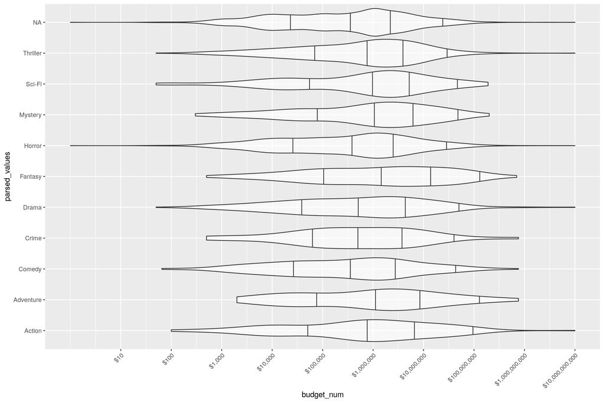

```r
hm %>% mutate(budget_num = readr::parse_number(budget)) %>%
  ggplot(data = .) +
  aes(x = parsed_values) +
  aes(y = budget_num) +
  geom_violin(alpha = .6, draw_quantiles = c(0.95, 0.75, 0.5, 0.25, 0.5), trim = TRUE) +
  scale_y_continuous(trans = "log10", breaks = 10^(1:10), labels = scales::dollar_format()) +
  coord_flip() +
  theme(axis.text.x = element_text(angle = 45, hjust = 1, vjust = 1))
```